# Lab-6

Alex Steiner

2024-02-21

## Homework 6

### Simulating and Fitting Data Distributions

Starting with dummy data

```r
library(ggplot2) # for graphics
library(MASS) # for maximum likelihood estimation
library(dplyr)
```

Reading in data.

```r
z <- read.csv("RisingPlate-July-BreadandButterFarm.csv")
str(z)
```

```
## 'data.frame':    640 obs. of  6 variables:
##  $ Farm     : chr  "Bread and Butter" "Bread and Butter" "Bread and Butter" "Bread and Butter" ...
##  $ Field    : chr  "BB-control" "BB-control" "BB-control" "BB-control" ...
##  $ Date     : chr  "7/20/2023" "7/20/2023" "7/20/2023" "7/20/2023" ...
##  $ AverageDM: int  4140 4980 4420 4840 7220 8480 5820 4420 5960 7360 ...
##  $ Latitude : num  44.4 44.4 44.4 44.4 44.4 ...
##  $ Longitude: num  -73.2 -73.2 -73.2 -73.2 -73.2 ...
```

### Plot histogram of data

Plot a histogram of the data, using a modification of the code from lecture. Here we are switching from qplot to ggplot for more graphics options. We are also re-scaling the y axis of the histogram from counts to density, so that the area under the histogram equals 1.0.

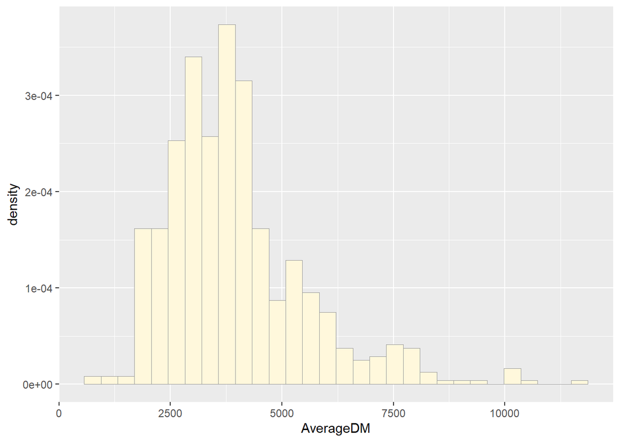

```r
p1 <- ggplot(data=z, aes(x=AverageDM, y=after_stat(density))) +
  geom_histogram(color="grey60",fill="cornsilk",size=0.2)
print(p1)
```

### Add empirical density curve

Now modify the code to add in a kernel density plot of the data. This is an empirical curve that is fitted to the data. It does not assume any particular probability distribution, but it smooths out the shape of the histogram:

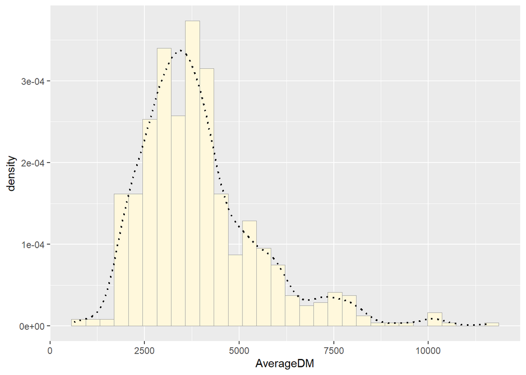

```r
p1 <-  p1 +  geom_density(linetype="dotted",size=0.75)
print(p1)
```

### Maximum liklihood params for normal

Next, fit a normal distribution to your data and grab the maximum likelihood estimators of the two parameters of the normal, the mean and the variance:

```r
normPars <- fitdistr(z$AverageDM,"normal")
print(normPars)
```

```
##       mean          sd
##   3942.90625   1577.82237
##  (  62.36891) (  44.10148)
```

```r
str(normPars)
```

```
## List of 5
##  $ estimate: Named num [1:2] 3943 1578
##   ..- attr(*, "names")= chr [1:2] "mean" "sd"
##  $ sd      : Named num [1:2] 62.4 44.1
##   ..- attr(*, "names")= chr [1:2] "mean" "sd"
##  $ vcov    : num [1:2, 1:2] 3890 0 0 1945
##   ..- attr(*, "dimnames")=List of 2
##   .. ..$ : chr [1:2] "mean" "sd"
##   .. ..$ : chr [1:2] "mean" "sd"
##  $ n       : int 640
##  $ loglik  : num -5621
##  - attr(*, "class")= chr "fitdistr"
```

```r
normPars$estimate["mean"] # note structure of getting a named attribute
```

```
##     mean
## 3942.906
```

### Normal Prob density

Now let’s call the dnorm function inside ggplot’s stat_function to generate the probability density for the normal distribution. Read about stat_function in the help system to see how you can use this to add a smooth function to any ggplot. Note that we first get the maximum likelihood parameters for a normal distribution fitted to thse data by calling fitdistr. Then we pass those parameters (meanML and sdML to stat_function):

```r
meanML <- normPars$estimate["mean"]
sdML <- normPars$estimate["sd"]

xval <- seq(0,max(z$AverageDM),len=length(z$AverageDM))

 stat <- stat_function(aes(x = xval, y = ..y..), fun = dnorm, colour="red", n = length(z$AverageDM), args = list(mean = meanML, sd = sdML))

 p1 + stat
```

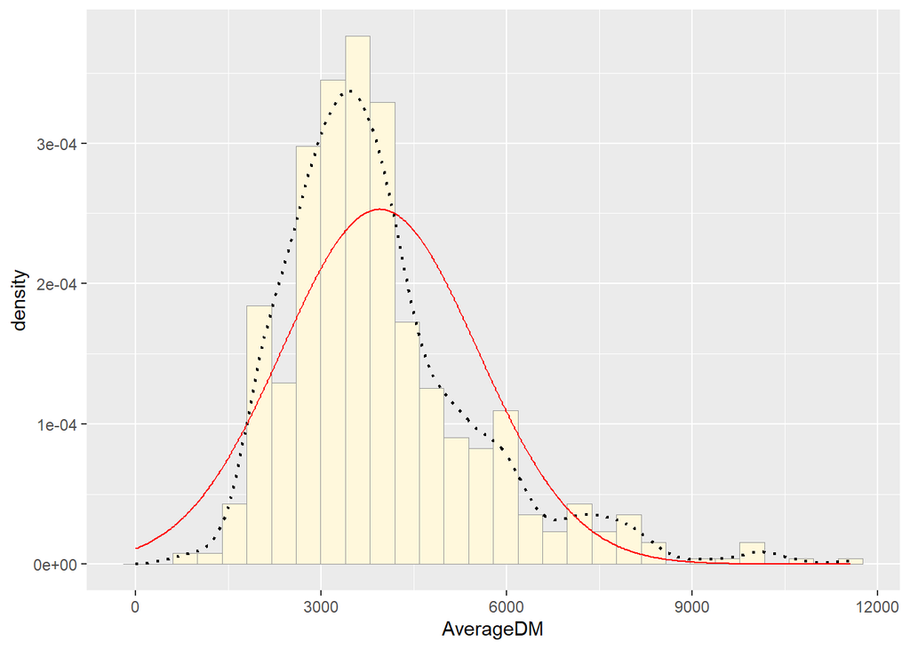

### Exponential prob density

Now let’s use the same template and add in the curve for the exponential:

```r
expoPars <- fitdistr(z$AverageDM,"exponential")
rateML <- expoPars$estimate["rate"]

stat2 <- stat_function(aes(x = xval, y = ..y..), fun = dexp, colour="blue", n = length(z$AverageDM), args = list(rate=rateML))
 p1 + stat + stat2
```

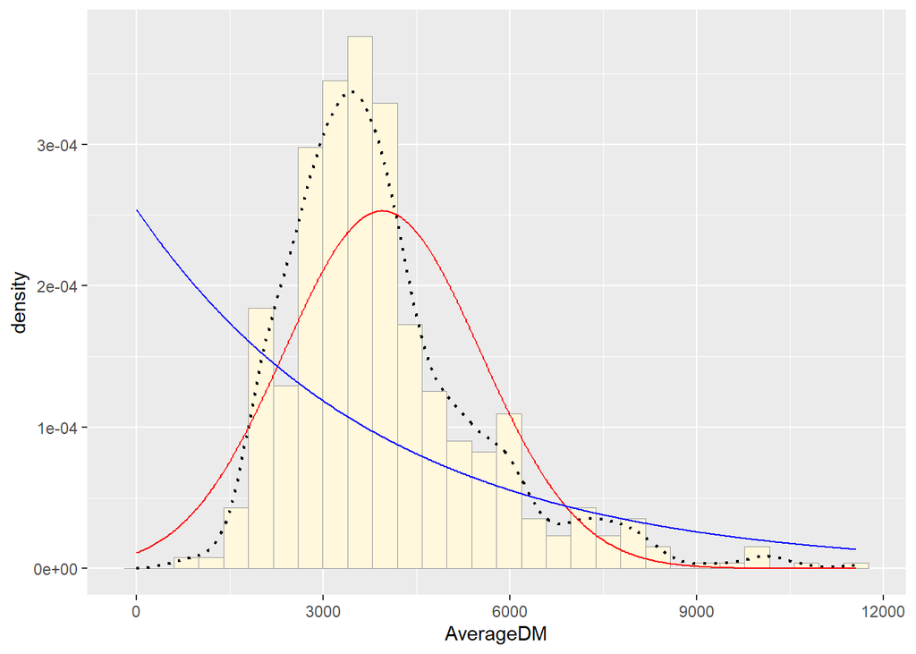

### Uniform prob density

For the uniform, we don’t need to use fitdistr because the maximum likelihood estimators of the two parameters are just the minimum and the maximum of the data:

```r
stat3 <- stat_function(aes(x = xval, y = ..y..), fun = dunif, colour="darkgreen", n = length(z$AverageDM), args = list(min=min(z$AverageDM), max=max(z$AverageDM)))
 p1 + stat + stat2 + stat3
```

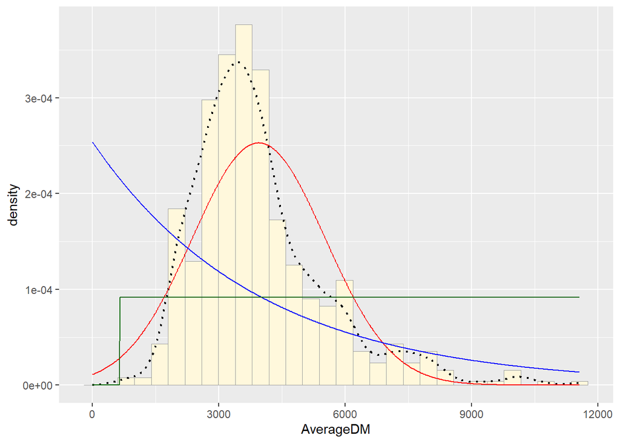

### Gamma prob density

```r
gammaPars <- fitdistr(z$AverageDM,"gamma")
shapeML <- gammaPars$estimate["shape"]
rateML <- gammaPars$estimate["rate"]

stat4 <- stat_function(aes(x = xval, y = ..y..), fun = dgamma, colour="brown", n = length(z$AverageDM), args = list(shape=shapeML, rate=rateML))
 p1 + stat + stat2 + stat3 + stat4
```

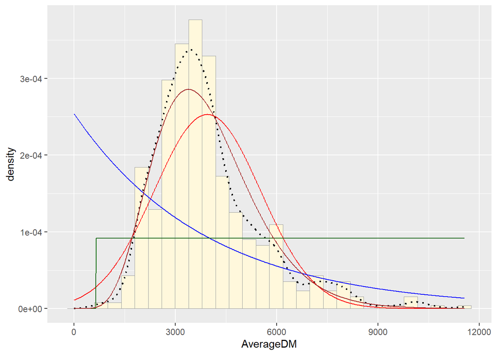

### Plot beta prob density

This one has to be shown in its own plot because the raw data must be rescaled so they are between 0 and 1, and then they can be compared to the beta.

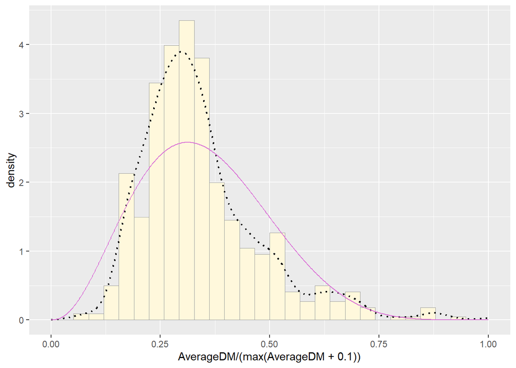

```r
pSpecial <- ggplot(data=z, aes(x=AverageDM/(max(AverageDM + 0.1)), y=after_stat(density))) +
  geom_histogram(color="grey60",fill="cornsilk",size=0.2) +
  xlim(c(0,1)) +
  geom_density(size=0.75,linetype="dotted")

betaPars <- fitdistr(x=z$AverageDM/max(z$AverageDM + 0.1),start=list(shape1=1,shape2=2),"beta")
shape1ML <- betaPars$estimate["shape1"]
shape2ML <- betaPars$estimate["shape2"]

statSpecial <- stat_function(aes(x = xval, y = ..y..), fun = dbeta, colour="orchid", n = length(z$AverageDM), args = list(shape1=shape1ML,shape2=shape2ML))
pSpecial + statSpecial
```

Simulate a new data set. Using the best-fitting distribution, go back to the code and get the maximum likelihood parameters. Use those to simulate a new data set, with the same length as your original vector, and plot that in a histogram and add the probability density curve. Right below that, generate a fresh histogram plot of the original data, and also include the probability density curve.

```r
gammaPars <- fitdistr(z$AverageDM,"gamma")
print(gammaPars)
```

```
##       shape           rate
##   7.0252093196   0.0017817339
##  (0.1922417439) (0.0000418298)
```

```r
str(gammaPars)
```

```
## List of 5
##  $ estimate: Named num [1:2] 7.02521 0.00178
##   ..- attr(*, "names")= chr [1:2] "shape" "rate"
##  $ sd      : Named num [1:2] 1.92e-01 4.18e-05
##   ..- attr(*, "names")= chr [1:2] "shape" "rate"
##  $ vcov    : num [1:2, 1:2] 3.70e-02 6.84e-06 6.84e-06 1.75e-09
##   ..- attr(*, "dimnames")=List of 2
##   .. ..$ : chr [1:2] "shape" "rate"
##   .. ..$ : chr [1:2] "shape" "rate"
##  $ loglik  : num -5552
##  $ n       : int 640
##  - attr(*, "class")= chr "fitdistr"
```

```r
gammaPars$estimate["shape"] # note structure of getting a named attribute
```

```
##    shape
## 7.025209
```

```r
gammaPars$estimate["rate"]
```

```
##        rate
## 0.001781734
```

```r
zsim <- rgamma(n=640,shape=7.025209, rate = 0.001781734)
zsim <- data.frame(1:640, zsim)
names(zsim) <- list("ID","myVar")
zsim <- zsim[zsim$myVar>0,]
str(zsim)
```

```
## 'data.frame':    640 obs. of  2 variables:
##  $ ID   : int  1 2 3 4 5 6 7 8 9 10 ...
##  $ myVar: num  2861 3480 3180 5223 4555 ...
```

```r
summary(zsim$myVar)
```

```
##    Min. 1st Qu.  Median    Mean 3rd Qu.    Max.
##   922.4  2816.8  3660.8  3915.0  4752.0 11375.0
```

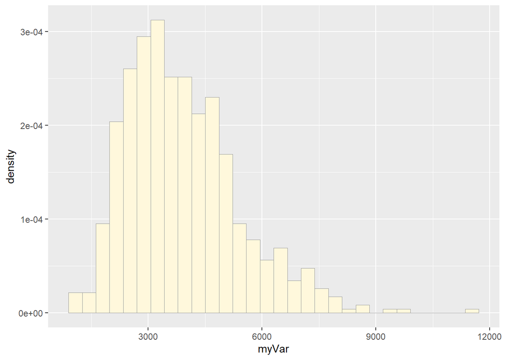

```r
p1sim <- ggplot(data=zsim, aes(x=myVar, y=after_stat(density))) +
  geom_histogram(color="grey60",fill="cornsilk",size=0.2)
print(p1sim)
```

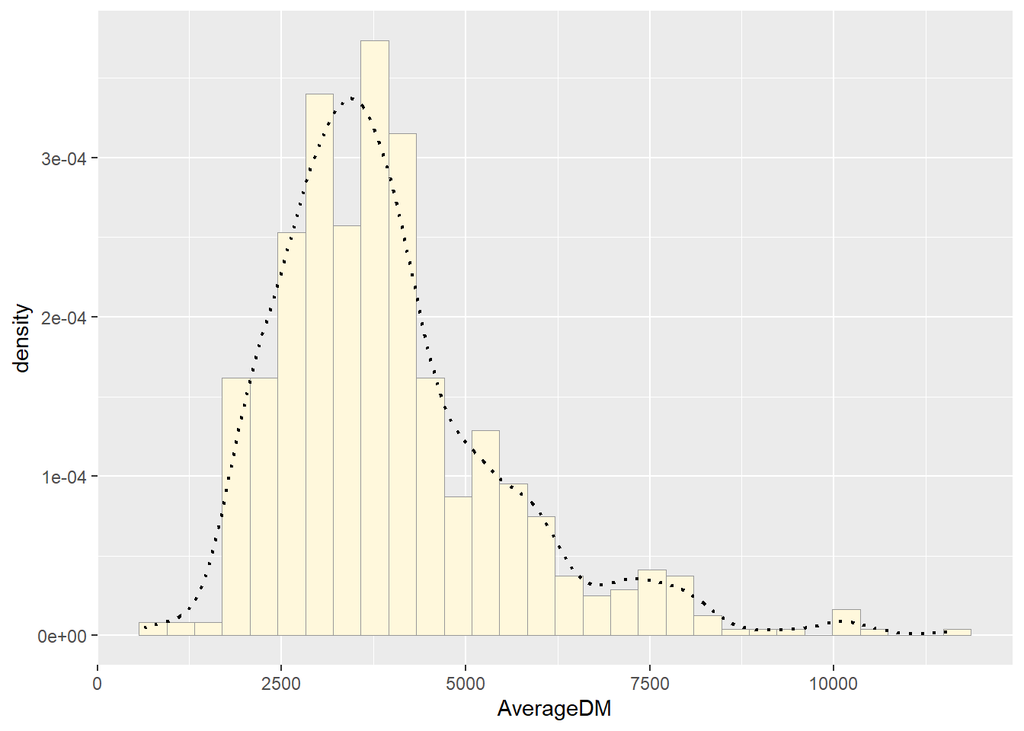

```r
print(p1)
```

How do the two histogram profiles compare? Do you think the model is doing a good job of simulating realistic data that match your original measurements? Why or why not?